# individual differences

Kianté Fernandez

9/15/2020

Here we are looking at the 320 subject (24 removed from VIF above 4)

If we define risk aversion as extracted subject models odds larger than 1 for the risk variable and loss aversion as lambda (-risk_beta/gain_beta) > 1 then here would be the breakdown.

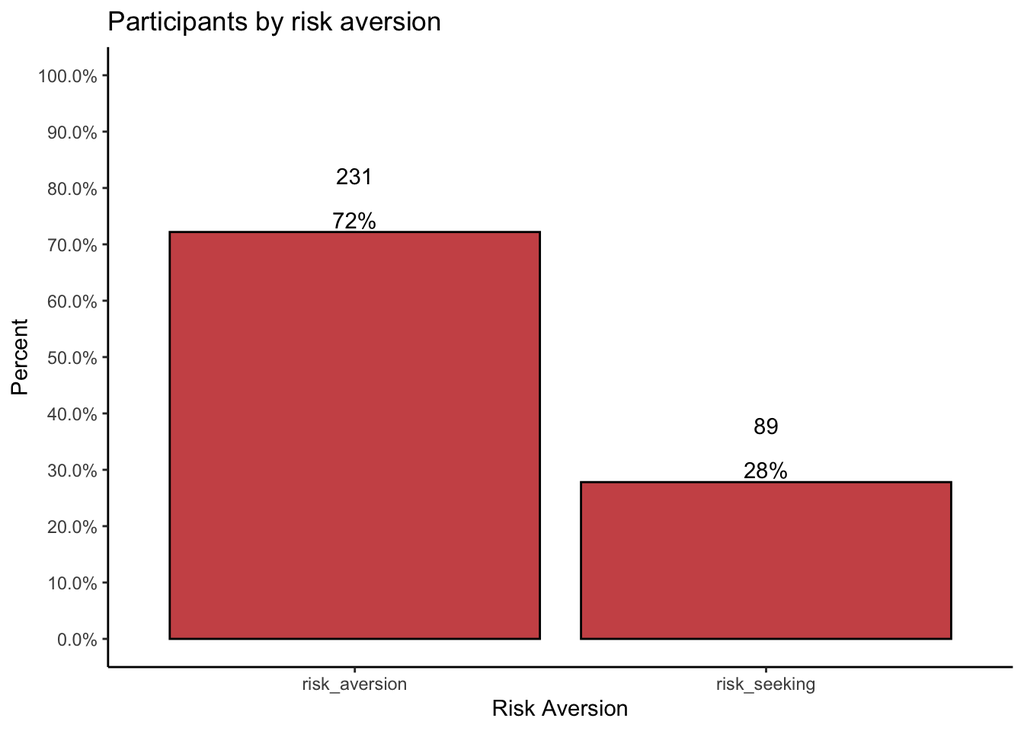

```r
plotdata <- data.h %>%
  count(risk_aversion) %>%
  mutate(pct = n / sum(n),
         pctlabel = paste0(round(pct*100), "%"))
# plot the bars as percentages,
# in decending order with bar labels
ggplot(plotdata,
       aes(x = reorder(risk_aversion, -pct),
           y = pct)) +
  geom_bar(stat = "identity",
           fill = "indianred3",
           color = "black") +
  geom_text(aes(label = pctlabel),
            vjust = -0.25) +
  geom_text(aes(label = n),
            vjust=-3) +
  scale_y_continuous(labels = percent, breaks=seq(0,1,.10), limits=c(0, 1)) +
  labs(x = "Risk Aversion",
       y = "Percent",
       title  = "Participants by risk aversion")+
  theme_classic()
```

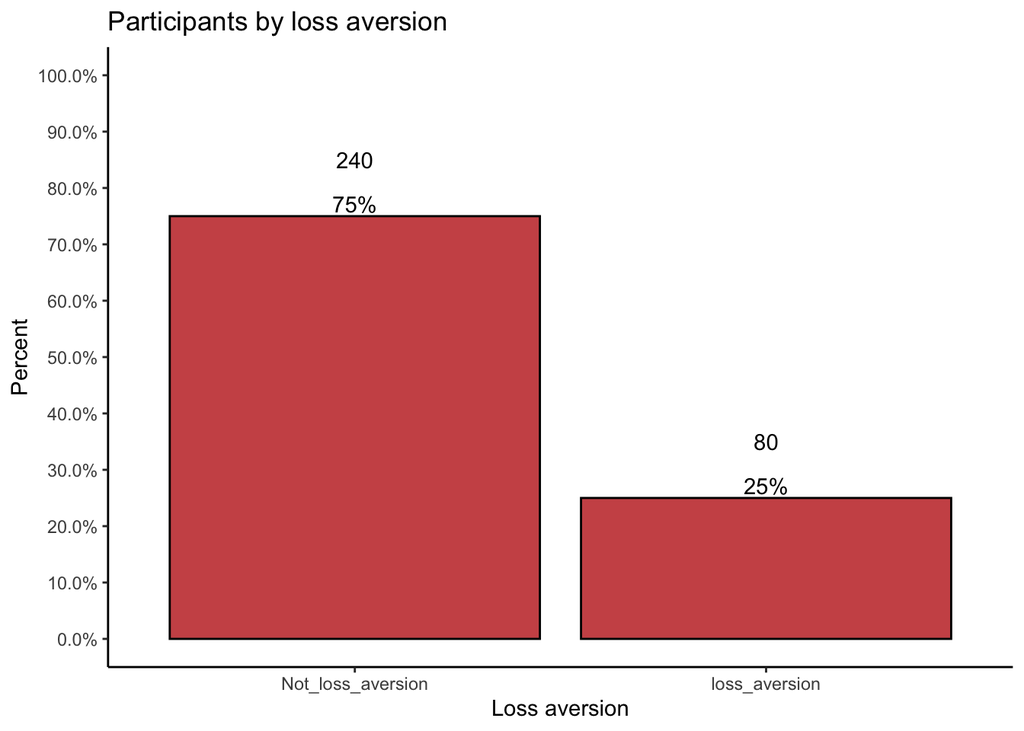

```r
plotdata <- data.h %>%
  count(loss_aversion) %>%
  mutate(pct = n / sum(n),
         pctlabel = paste0(round(pct*100), "%"))


# plot the bars as percentages,
# in decending order with bar labels
ggplot(plotdata,
       aes(x = reorder(loss_aversion, -pct),
           y = pct)) +
  geom_bar(stat = "identity",
           fill = "indianred3",
           color = "black") +
  geom_text(aes(label = pctlabel),
            vjust = -0.25) +
  geom_text(aes(label = n),
            vjust=-3) +
  scale_y_continuous(labels = percent, breaks=seq(0,1,.10), limits=c(0, 1)) +
  labs(x = "Loss aversion",
       y = "Percent",
       title  = "Participants by loss aversion") +
    theme_classic()
```

# Dominate subjects

Dominate response blurb In any discrete choice task, some participants dominate on a single attribute; that is, they always choose the alternative with the better level of the most important (dominant) attribute, regardless of the levels of the other attributes presented in the task. There are two reasons why participants might answer in this way. First, these decisions may reflect participants true preferences, and the choices presented in the task do not include combinations of other attributes that are sufficiently attractive to induce participants to choose an alternative that does not include the better level of the dominant attribute. Alternatively, participants simply may focus on only a single attribute as a way of simplifying the task of answering the trade-off questions. In the latter case, while aligned with what we’d expect from a prospect theory, from a statistical perspective their decisions will overstate the relative actual mean importance of the dominant attribute. To control for this, we first tested for differences in dominate and non-dominate response. A dominate response was identified as a selection solely of a single treatment option at or above 80% of the total amount of trials (56 trials selected for a single option) two samples t-test showed a significant difference in dominate and non-dominate responses. Thus, we excluded subjects with dominate response from our main analysis.

Testing for difference in dominate subject effects for risk (model 1) and gain (model 2)

| method | estimate | statistic | conf.low | conf.high | p.value |
| --- | --- | --- | --- | --- | --- |
| Two Sample t-test | 0.0010899 | 1.970753 | 0.0000018 | 0.0021779 | 0.0496191 |
| Two Sample t-test | -0.0028673 | -4.883210 | -0.0040226 | -0.0017121 | 0.0000017 |

Marginal effect t test with and without dominate subjects

| method | estimate | statistic | conf.low | conf.high | p.value |
| --- | --- | --- | --- | --- | --- |
| Paired t-test | -0.0005358 | -1.564323 | -0.0012097 | 0.0001381 | 0.1187332 |
| Paired t-test | -0.0008413 | -2.140131 | -0.0016153 | -0.0000673 | 0.0332608 |

Individual differences

**In the R01 aims, I'm predicting that "more affluent, educated, liberal, and younger individuals will be less risk-averse and more benefit-driven." Is this true in our data?**

**Are more affluent less risk-averse and more benefit-driven?**

Predicting Risk given Continuous Income

| term | estimate | std.error | statistic | p.value |
| --- | --- | --- | --- | --- |
| (Intercept) | -0.0022772 | 0.0004439 | -5.1298583 | 0.0000006 |
| Income | 0.0000000 | 0.0000000 | -0.4050661 | 0.6857594 |

Predicting Risk given Categorical Income

| term | estimate | std.error | statistic | p.value |
| --- | --- | --- | --- | --- |
| (Intercept) | -0.0023470 | 0.0004688 | -5.0065676 | 0.0000010 |
| income_recode25,000-50,000 | -0.0002304 | 0.0006178 | -0.3729467 | 0.7094943 |
| income_recode50,000-75,000 | 0.0003325 | 0.0006932 | 0.4796448 | 0.6318863 |
| income_recode> 75,000 | -0.0005209 | 0.0007903 | -0.6591465 | 0.5103895 |

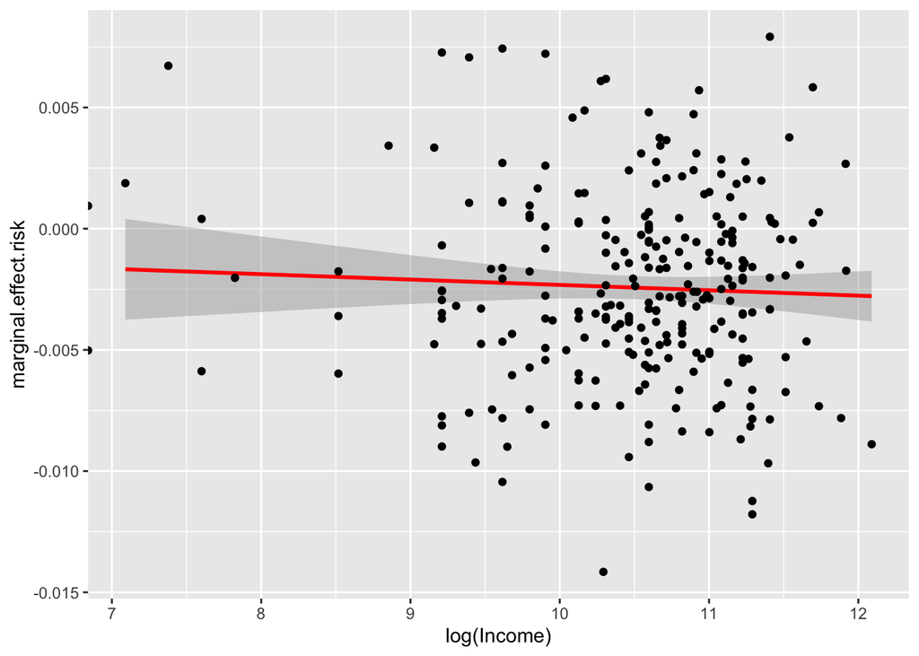

Descriptives for risk by income

| income_recode | n | mean | sd | se | ci |
| --- | --- | --- | --- | --- | --- |
| < 25,000 | 70 | -0.0023470 | 0.0043971 | 0.0005256 | 0.0010485 |
| 25,000-50,000 | 95 | -0.0025775 | 0.0036390 | 0.0003733 | 0.0007413 |
| 50,000-75,000 | 59 | -0.0020146 | 0.0030839 | 0.0004015 | 0.0008037 |
| > 75,000 | 38 | -0.0028680 | 0.0047606 | 0.0007723 | 0.0015648 |

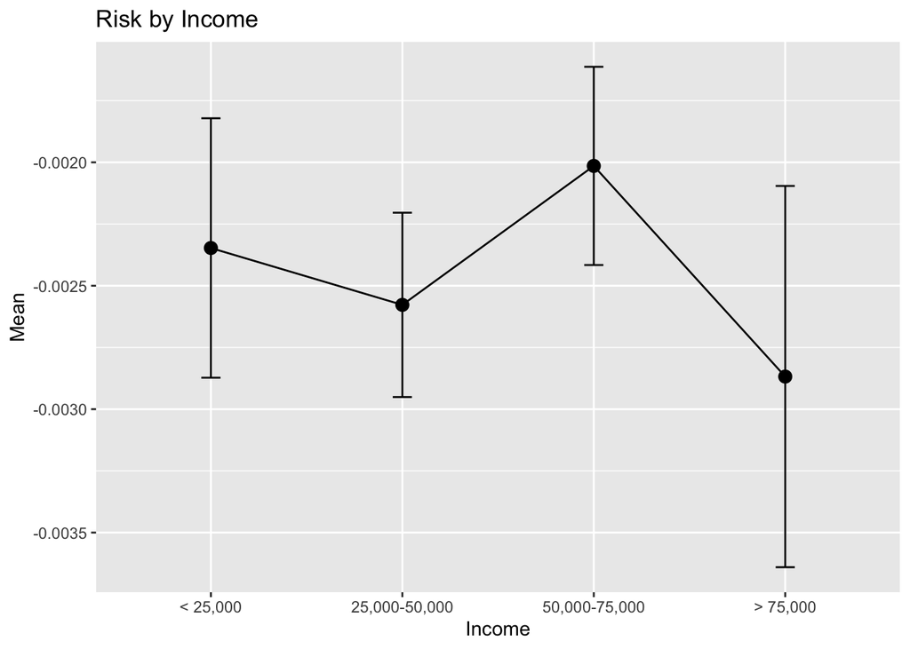

Predicting Gain given Continuous Income

| term | estimate | std.error | statistic | p.value |
| --- | --- | --- | --- | --- |
| (Intercept) | 0.0036743 | 0.0004776 | 7.6925112 | 0.0000000 |
| Income | 0.0000000 | 0.0000000 | -0.9519263 | 0.3420117 |

| term | estimate | std.error | statistic | p.value |
| --- | --- | --- | --- | --- |
| (Intercept) | 0.0034744 | 0.0005068 | 6.8553910 | 0.0000000 |
| income_recode25,000-50,000 | -0.0001330 | 0.0006679 | -0.1991855 | 0.8422745 |
| income_recode50,000-75,000 | -0.0002115 | 0.0007494 | -0.2822728 | 0.7779606 |
| income_recode> 75,000 | -0.0005464 | 0.0008544 | -0.6394818 | 0.5230770 |

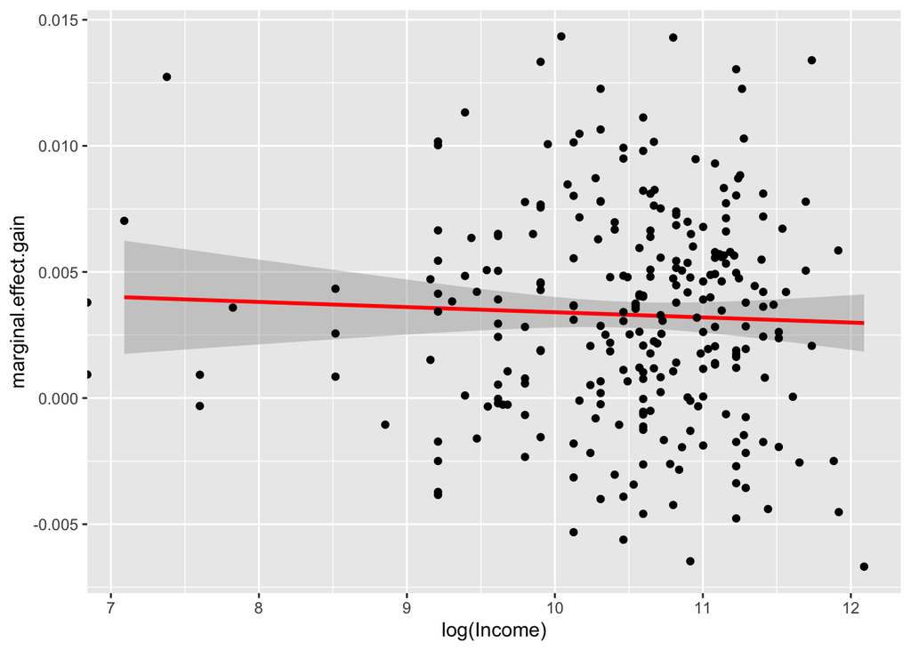

Descriptives for gain by income

| income_recode | n | mean | sd | se | ci |
| --- | --- | --- | --- | --- | --- |
| < 25,000 | 70 | 0.0034744 | 0.0043489 | 0.0005198 | 0.0010370 |
| 25,000-50,000 | 95 | 0.0033414 | 0.0041717 | 0.0004280 | 0.0008498 |
| 50,000-75,000 | 59 | 0.0032629 | 0.0038123 | 0.0004963 | 0.0009935 |
| > 75,000 | 38 | 0.0029281 | 0.0048073 | 0.0007799 | 0.0015801 |

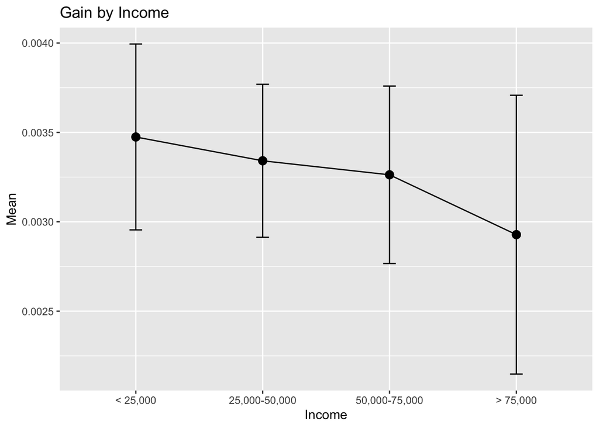

*We did not find differences across Income for Risk or Gain in our sample*

**Are more educated less risk-averse and more benefit-driven?**

Predicting Risk given Categorical Education

| term | estimate | std.error | statistic | p.value |
| --- | --- | --- | --- | --- |
| (Intercept) | -0.0025836 | 0.0004175 | -6.1880879 | 0.0000000 |
| education_recodeUndergraduate | 0.0001105 | 0.0005281 | 0.2092031 | 0.8344529 |
| education_recodePostgraduate | 0.0008611 | 0.0008051 | 1.0695132 | 0.2858266 |

Descriptives for risk by education

| education_recode | n | mean | sd | se | ci |
| --- | --- | --- | --- | --- | --- |
| HighSchool | 87 | -0.0025836 | 0.0038509 | 0.0004129 | 0.0008207 |
| Undergraduate | 145 | -0.0024731 | 0.0038946 | 0.0003234 | 0.0006393 |
| Postgraduate | 32 | -0.0017225 | 0.0040113 | 0.0007091 | 0.0014462 |

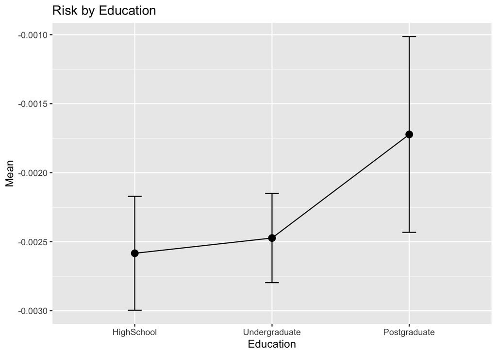

Pairwise comparisons for risk by education

| group1 | group2 | mean.difference | p.value | significance | test.details |
| --- | --- | --- | --- | --- | --- |
| HighSchool | Postgraduate | 0.0008611 | 0.2858266 | ns | Student's t-test |
| HighSchool | Undergraduate | 0.0001105 | 0.8344529 | ns | Student's t-test |
| Undergraduate | Postgraduate | 0.0007506 | 0.3246181 | ns | Student's t-test |

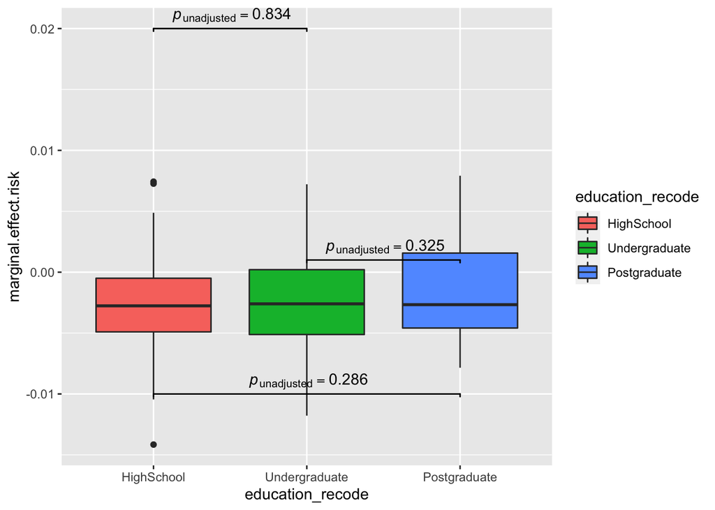

Predicting Gain given Categorical Education

| term | estimate | std.error | statistic | p.value |
| --- | --- | --- | --- | --- |
| (Intercept) | 0.0038856 | 0.0004457 | 8.718768 | 0.0000000 |
| education_recodeUndergraduate | -0.0005811 | 0.0005637 | -1.030766 | 0.3036049 |
| education_recodePostgraduate | -0.0023999 | 0.0008594 | -2.792538 | 0.0056166 |

Descriptives for gain by education

| education_recode | n | mean | sd | se | ci |
| --- | --- | --- | --- | --- | --- |
| HighSchool | 87 | 0.0038856 | 0.0037812 | 0.0004054 | 0.0008059 |
| Undergraduate | 145 | 0.0033045 | 0.0043646 | 0.0003625 | 0.0007164 |
| Postgraduate | 32 | 0.0014856 | 0.0041622 | 0.0007358 | 0.0015006 |

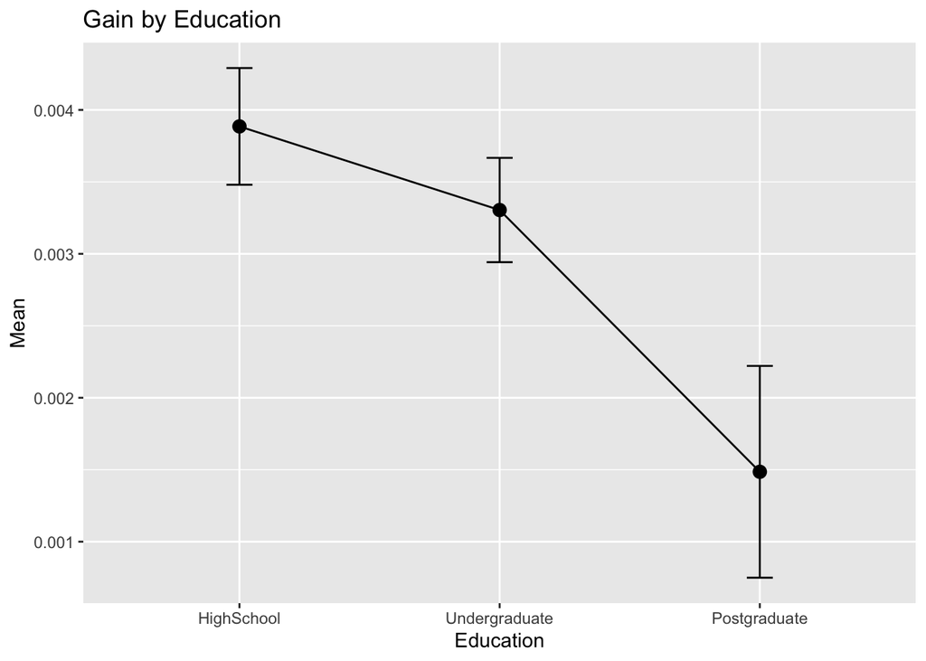

Pairwise comparisons for gain by education

mean.difference

p.value

significance

test.details

HighSchool

Postgraduate

-0.0023999

0.0056166

Student's t-test

HighSchool

Undergraduate

-0.0005811

0.3036049

ns

Student's t-test

Undergraduate

Postgraduate

-0.0018189

0.0259108

Student's t-test

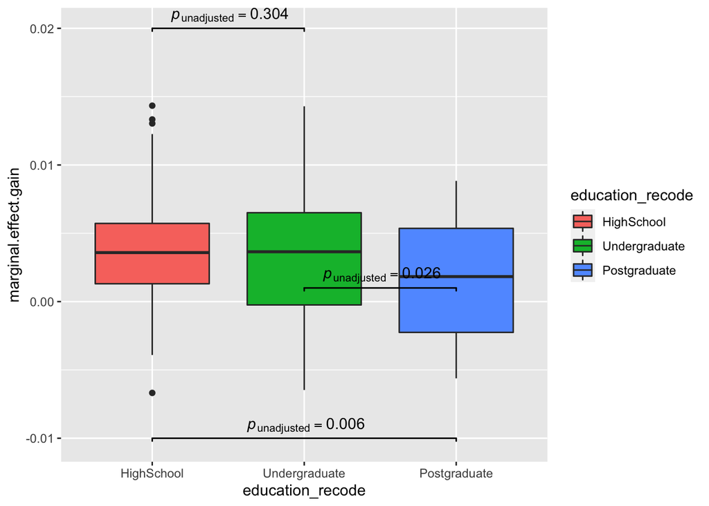

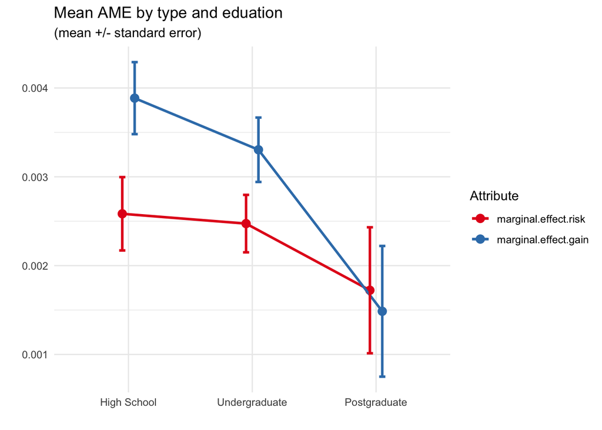

**Are liberals less risk-averse and more benefit-driven?**

Predicting Risk given Continuous Political

| term | estimate | std.error | statistic | p.value |
| --- | --- | --- | --- | --- |
| (Intercept) | -0.0021600 | 0.0002594 | -8.326923 | 0.0000000 |
| conservatismFactor | 0.0000884 | 0.0000325 | 2.717155 | 0.0070217 |

Predicting Risk given Categorical Political

| term | estimate | std.error | statistic | p.value |
| --- | --- | --- | --- | --- |
| (Intercept) | -0.0029269 | 0.0003350 | -8.7366997 | 0.0000000 |
| Political_PartyRepublican | 0.0016688 | 0.0006381 | 2.6153757 | 0.0094317 |
| Political_PartyIndependent | 0.0005526 | 0.0005746 | 0.9616764 | 0.3371022 |
| Political_PartyOther | 0.0003856 | 0.0012163 | 0.3170409 | 0.7514660 |

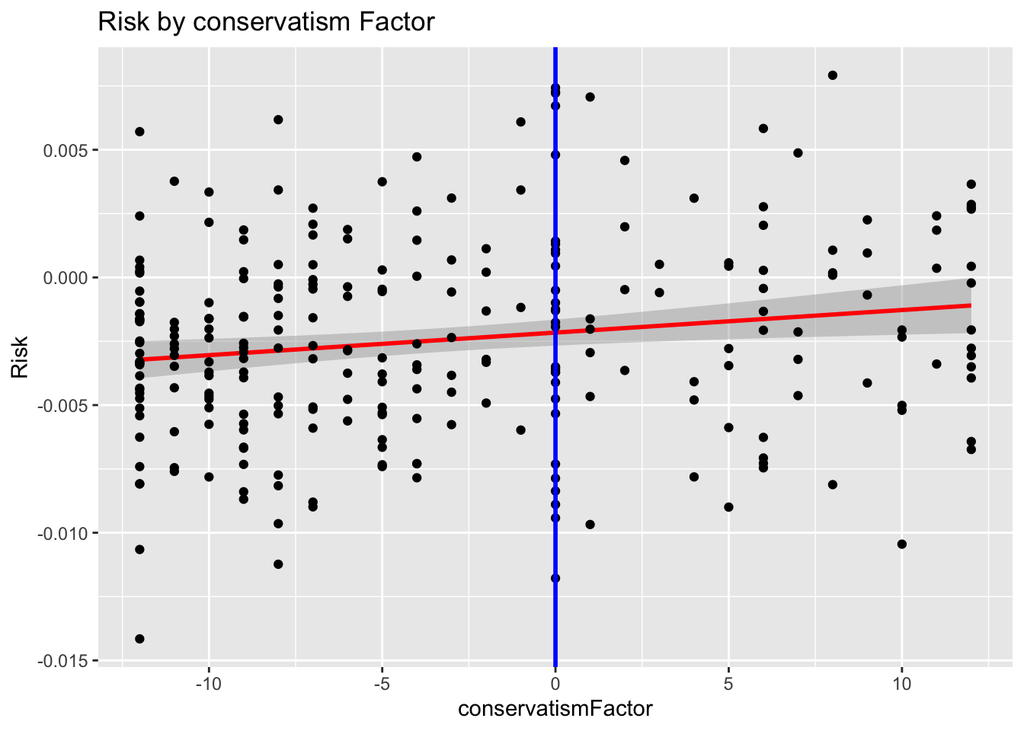

Descriptives for risk by political party

| Political_Party | n | mean | sd | se | ci |
| --- | --- | --- | --- | --- | --- |
| Democrat | 134 | -0.0029269 | 0.0035521 | 0.0003069 | 0.0006069 |
| Republican | 51 | -0.0012581 | 0.0039371 | 0.0005513 | 0.0011073 |
| Independent | 69 | -0.0023743 | 0.0042385 | 0.0005103 | 0.0010182 |
| Other | 11 | -0.0025413 | 0.0050039 | 0.0015087 | 0.0033617 |

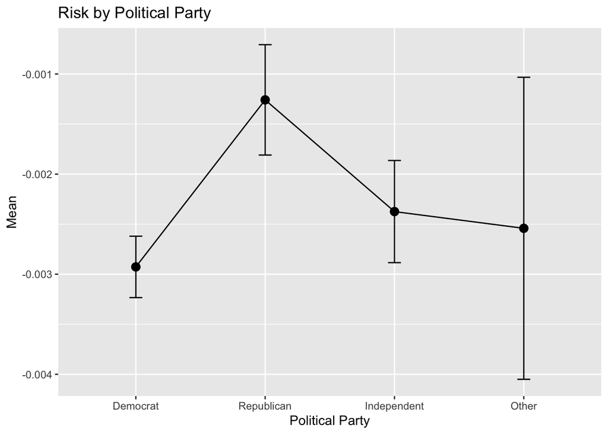

Pairwise comparisons for risk by political party

| group1 | group2 | mean.difference | p.value | significance | test.details |
| --- | --- | --- | --- | --- | --- |
| Democrat | Independent | 0.0005526 | 0.3371022 | ns | Student's t-test |
| Democrat | Other | 0.0003856 | 0.7514660 | ns | Student's t-test |
| Democrat | Republican | 0.0016688 | 0.0094317 | ** | Student's t-test |
| Independent | Other | -0.0001670 | 0.8945922 | ns | Student's t-test |
| Republican | Independent | -0.0011162 | 0.1203036 | ns | Student's t-test |
| Republican | Other | -0.0012831 | 0.3205195 | ns | Student's t-test |

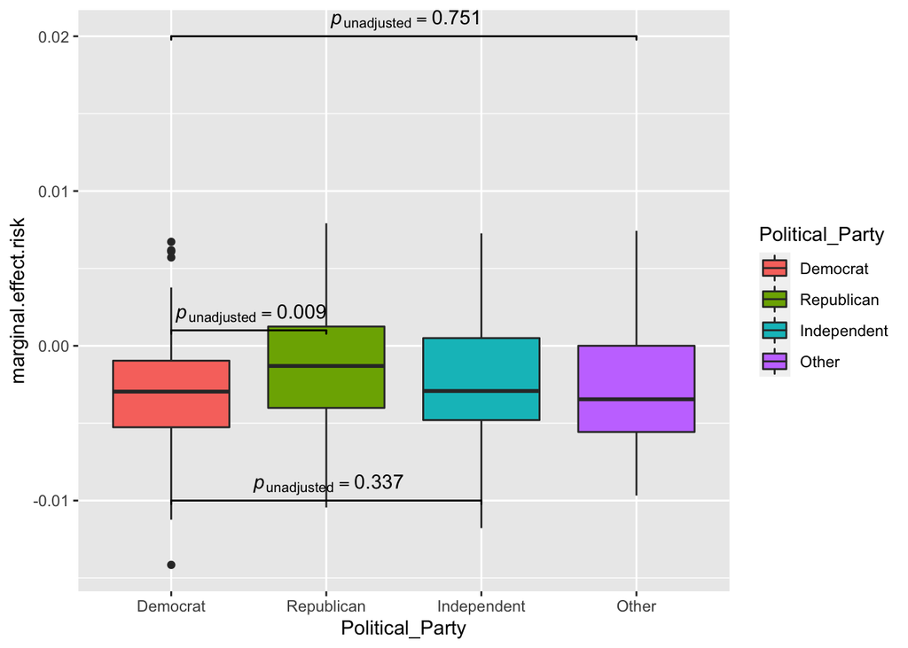

Predicting Gain given Continuous Political

| term | estimate | std.error | statistic | p.value |
| --- | --- | --- | --- | --- |
| (Intercept) | 0.0034500 | 0.0002816 | 12.250735 | 0.0000000 |
| conservatismFactor | 0.0000504 | 0.0000353 | 1.426425 | 0.1549316 |

Predicting Gain given Categorical Political

| term | estimate | std.error | statistic | p.value |
| --- | --- | --- | --- | --- |
| (Intercept) | 0.0032977 | 0.0003621 | 9.1074080 | 0.0000000 |
| Political_PartyRepublican | 0.0008737 | 0.0006896 | 1.2668470 | 0.2063393 |
| Political_PartyIndependent | -0.0006547 | 0.0006211 | -1.0541381 | 0.2927946 |
| Political_PartyOther | -0.0001980 | 0.0013146 | -0.1506301 | 0.8803839 |

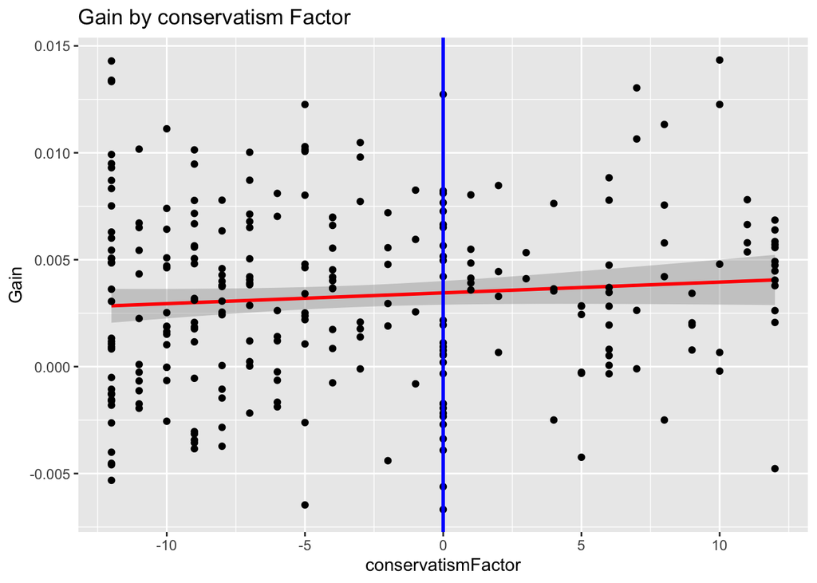

Descriptives for gain by political party

| Political_Party | n | mean | sd | se | ci |
| --- | --- | --- | --- | --- | --- |
| Democrat | 134 | 0.0032977 | 0.0044328 | 0.0003829 | 0.0007574 |
| Republican | 51 | 0.0041713 | 0.0040257 | 0.0005637 | 0.0011323 |
| Independent | 69 | 0.0026430 | 0.0039675 | 0.0004776 | 0.0009531 |
| Other | 11 | 0.0030997 | 0.0030214 | 0.0009110 | 0.0020298 |

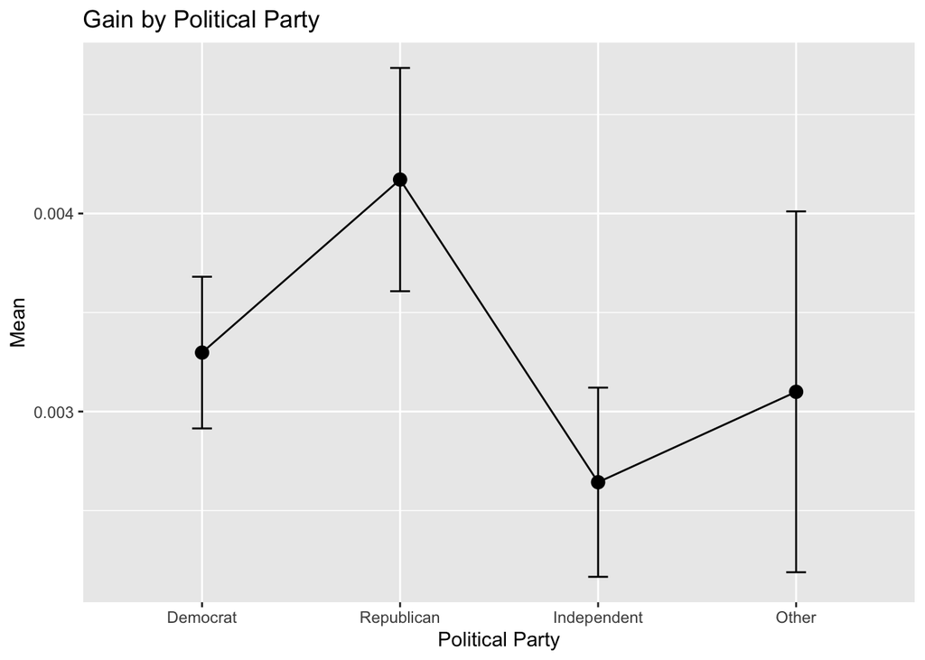

Pairwise comparisons for gain by political party

mean.difference

p.value

significance

test.details

Democrat

Independent

-0.0006547

0.2927946

ns

Student's t-test

Democrat

Other

-0.0001980

0.8803839

ns

Student's t-test

Democrat

Republican

0.0008737

0.2063393

ns

Student's t-test

Independent

Other

0.0004567

0.7374496

ns

Student's t-test

Republican

Independent

-0.0015283

0.0493707

Student's t-test

Republican

Other

-0.0010717

0.4425300

ns

Student's t-test

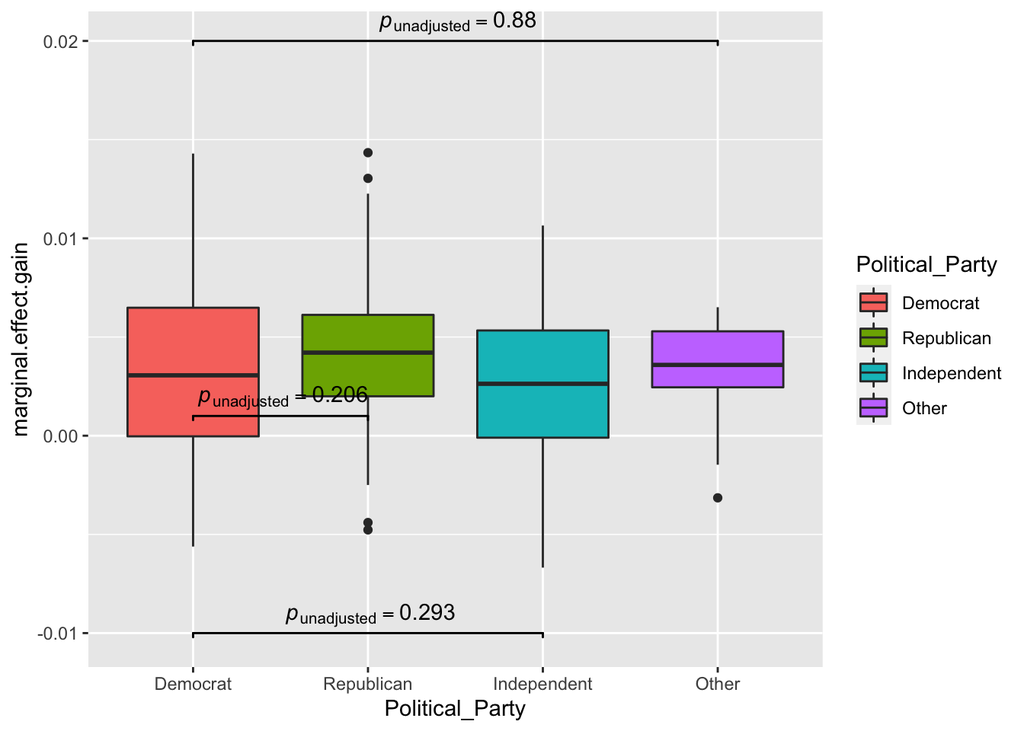

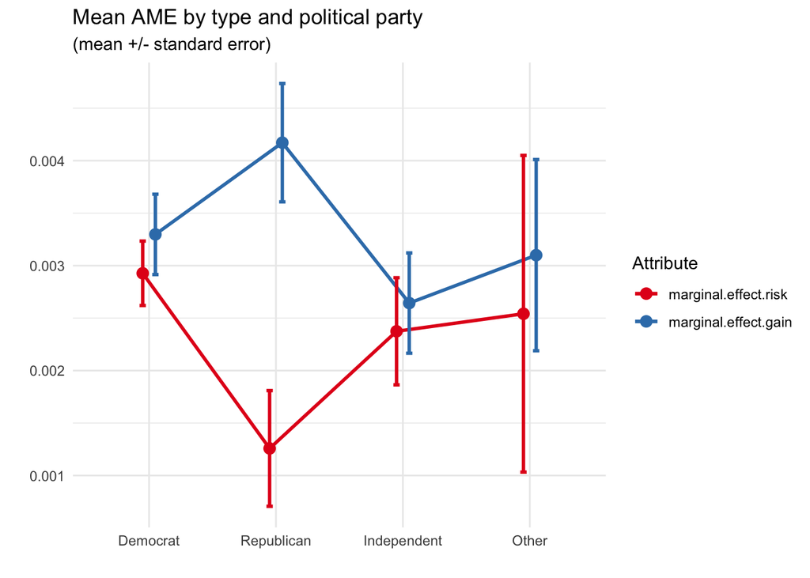

**Are younger individuals less risk-averse and more benefit-driven?**

Predicting Risk given Continuous Age

| term | estimate | std.error | statistic | p.value |
| --- | --- | --- | --- | --- |
| (Intercept) | -0.0031955 | 0.0008309 | -3.8458903 | 0.0001508 |
| age | 0.0000204 | 0.0000217 | 0.9424419 | 0.3468313 |

Predicting Risk given Categorical Age

| term | estimate | std.error | statistic | p.value |
| --- | --- | --- | --- | --- |
| (Intercept) | -0.0022532 | 0.0008964 | -2.5134289 | 0.0125592 |
| age_recode25-49 | -0.0002803 | 0.0009377 | -0.2989430 | 0.7652214 |
| age_recode50-75 | 0.0002657 | 0.0010764 | 0.2468597 | 0.8052109 |

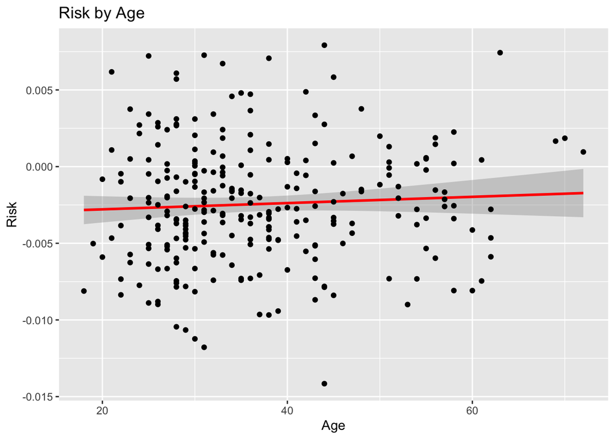

Descriptives for risk by age

| age_recode | n | mean | sd | se | ci |
| --- | --- | --- | --- | --- | --- |
| 18-24 | 19 | -0.0022532 | 0.0042658 | 0.0009786 | 0.0020561 |
| 25-49 | 202 | -0.0025335 | 0.0039540 | 0.0002782 | 0.0005486 |
| 50-75 | 43 | -0.0019874 | 0.0035023 | 0.0005341 | 0.0010778 |

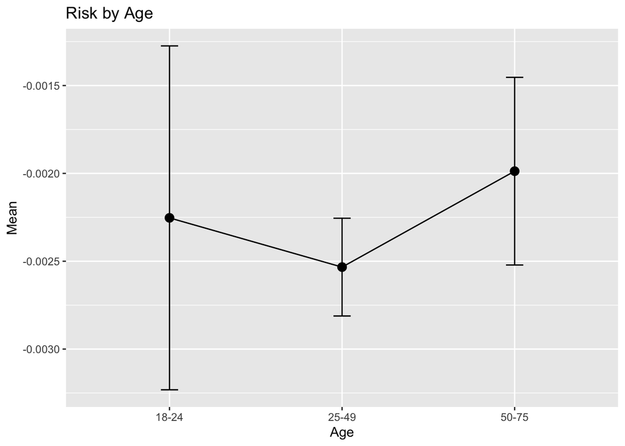

Pairwise comparisons for risk by age

| group1 | group2 | mean.difference | p.value | significance | test.details |
| --- | --- | --- | --- | --- | --- |
| 18-24 | 25-49 | -0.0002803 | 0.7652214 | ns | Student's t-test |
| 18-24 | 50-75 | 0.0002657 | 0.8052109 | ns | Student's t-test |
| 25-49 | 50-75 | 0.0005460 | 0.4061459 | ns | Student's t-test |

Predicting Gain given Continuous Age

| term | estimate | std.error | statistic | p.value |
| --- | --- | --- | --- | --- |
| (Intercept) | 0.0032565 | 0.0008946 | 3.6402629 | 0.0003279 |
| age | 0.0000008 | 0.0000233 | 0.0357184 | 0.9715340 |

Predicting Gain given Categorical Age

| term | estimate | std.error | statistic | p.value |
| --- | --- | --- | --- | --- |
| (Intercept) | 0.0040087 | 0.0009642 | 4.1574788 | 0.0000437 |
| age_recode25-49 | -0.0007429 | 0.0010086 | -0.7365675 | 0.4620469 |
| age_recode50-75 | -0.0008061 | 0.0011578 | -0.6962431 | 0.4868962 |

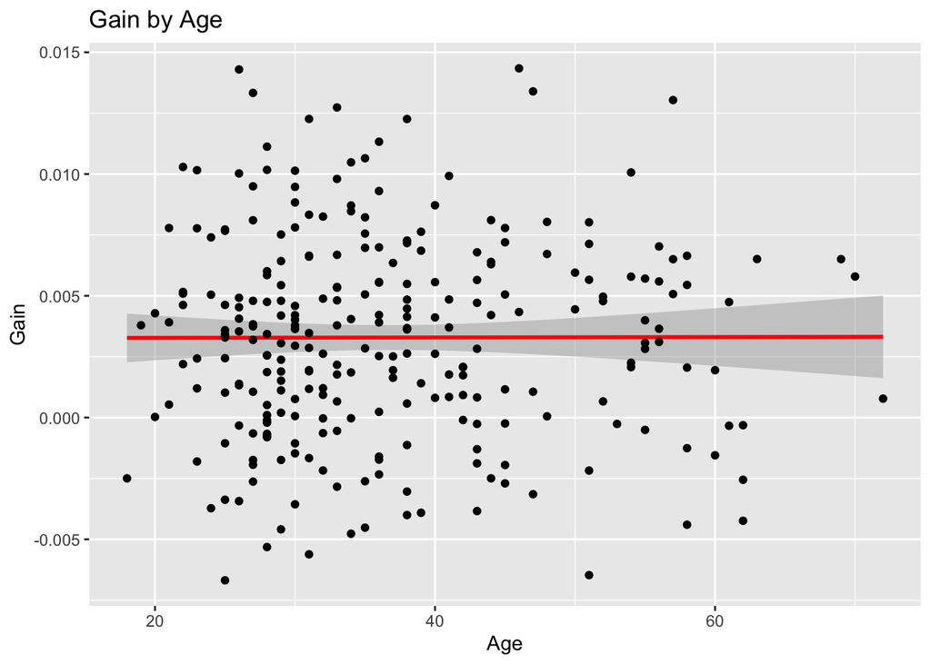

Descriptives for gain by age

| age_recode | n | mean | sd | se | ci |
| --- | --- | --- | --- | --- | --- |
| 18-24 | 19 | 0.0040087 | 0.0037748 | 0.0008660 | 0.0018194 |
| 25-49 | 202 | 0.0032659 | 0.0042760 | 0.0003009 | 0.0005932 |
| 50-75 | 43 | 0.0032026 | 0.0040206 | 0.0006131 | 0.0012374 |

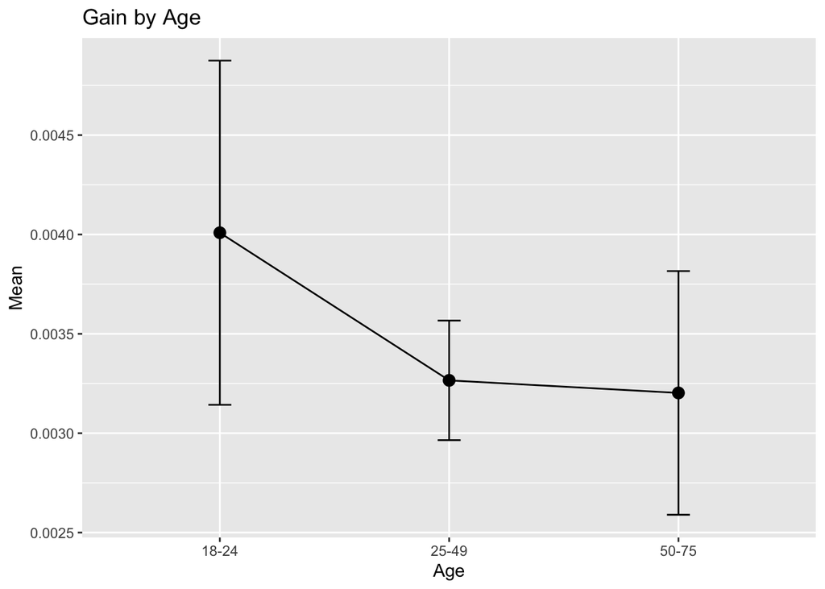

Pairwise comparisons for gain by age

| group1 | group2 | mean.difference | p.value | significance | test.details |
| --- | --- | --- | --- | --- | --- |
| 18-24 | 25-49 | -0.0007429 | 0.4620469 | ns | Student's t-test |
| 18-24 | 50-75 | -0.0008061 | 0.4868962 | ns | Student's t-test |
| 25-49 | 50-75 | -0.0000633 | 0.9286646 | ns | Student's t-test |

*We did not find a significant difference in Risk or Gain as a function of age*

```
##
## Loadings:
##                   ML1
## Religiosity        0.961
## Spirituality       0.803
## AttendChurch       0.826
## ReligiousActivity  0.853
## ReligionChanged   -0.747
##
##                  ML1
## SS loadings    3.535
## Proportion Var 0.707
```

Predicting Risk given Continuous Religious

| term | estimate | std.error | statistic | p.value |
| --- | --- | --- | --- | --- |
| (Intercept) | -0.0024458 | 0.0002380 | -10.276585 | 0.000000 |
| ReligiousFactor | 0.0005319 | 0.0002293 | 2.319685 | 0.021124 |

Predicting Risk given Categorical Religious

| term | estimate | std.error | statistic | p.value |
| --- | --- | --- | --- | --- |
| (Intercept) | -0.0029621 | 0.0003333 | -8.886234 | 0.0000000 |
| ReligiositySomewhat Religious | 0.0006749 | 0.0005402 | 1.249333 | 0.2126626 |
| ReligiosityVery Religious | 0.0019913 | 0.0007615 | 2.615018 | 0.0094413 |
| ReligiosityExtremely Religious | 0.0011382 | 0.0010541 | 1.079826 | 0.2812167 |

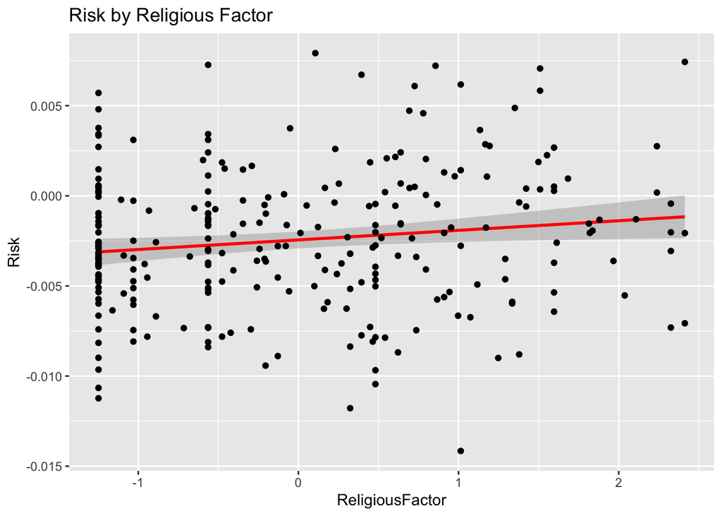

Descriptives for risk by Religion

| ReligionNow_recode | n | mean | sd | se | ci |
| --- | --- | --- | --- | --- | --- |
| Christianity | 116 | -0.0018009 | 0.0038413 | 0.0003567 | 0.0007065 |
| Other | 24 | -0.0023828 | 0.0052536 | 0.0010724 | 0.0022184 |
| Not_religious | 125 | -0.0030564 | 0.0035943 | 0.0003215 | 0.0006363 |

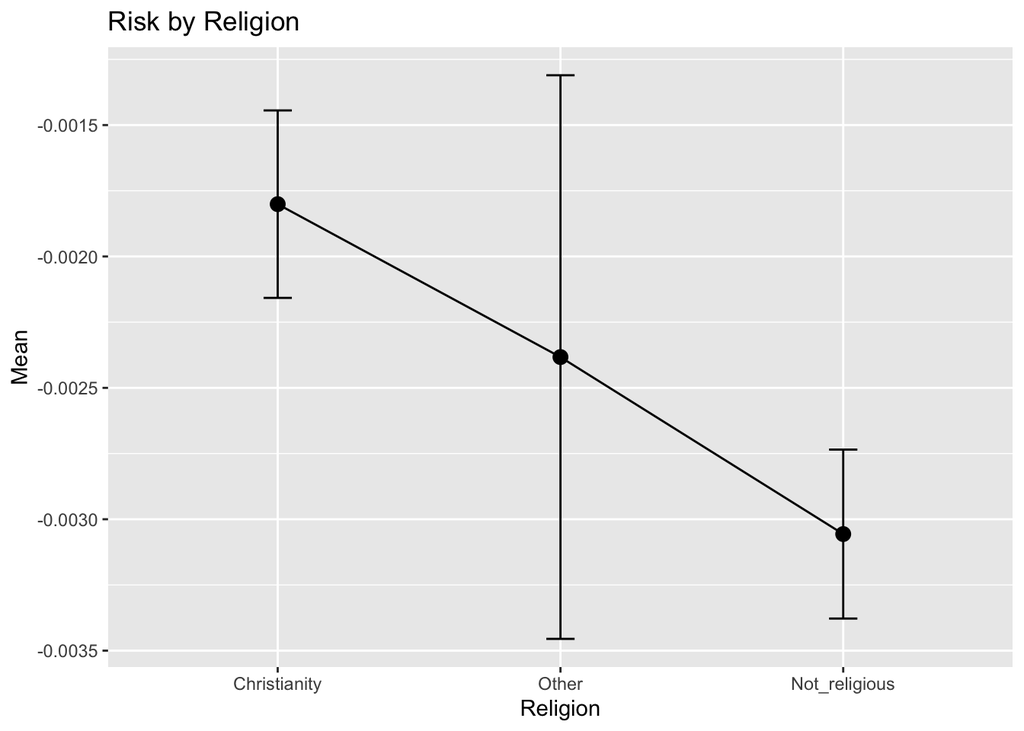

Descriptives for risk by religiosity

| Religiosity | n | mean | sd | se | ci |
| --- | --- | --- | --- | --- | --- |
| Not Religious | 135 | -0.0029621 | 0.0034596 | 0.0002978 | 0.0005889 |
| Somewhat Religious | 83 | -0.0022872 | 0.0043757 | 0.0004803 | 0.0009555 |
| Very Religious | 32 | -0.0009708 | 0.0042193 | 0.0007459 | 0.0015212 |
| Extremely Religious | 15 | -0.0018239 | 0.0036774 | 0.0009495 | 0.0020365 |

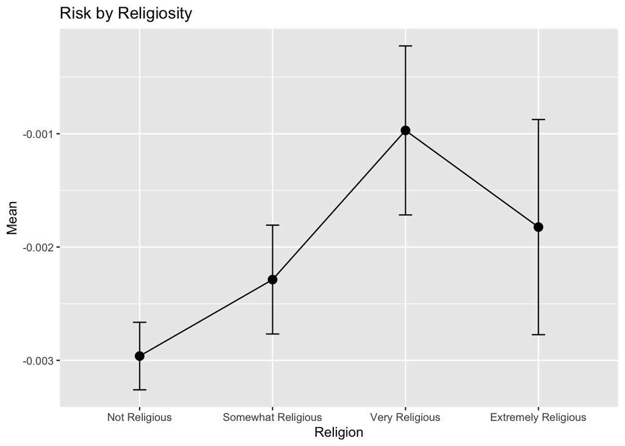

Pairwise comparisons for risk by religiosity

| group1 | group2 | mean.difference | p.value | significance | test.details |
| --- | --- | --- | --- | --- | --- |
| Not Religious | Extremely Religious | 0.0011382 | 0.2812167 | ns | Student's t-test |
| Not Religious | Somewhat Religious | 0.0006749 | 0.2126626 | ns | Student's t-test |
| Not Religious | Very Religious | 0.0019913 | 0.0094413 | ** | Student's t-test |
| Somewhat Religious | Extremely Religious | 0.0004633 | 0.6701713 | ns | Student's t-test |
| Somewhat Religious | Very Religious | 0.0013164 | 0.1035816 | ns | Student's t-test |
| Very Religious | Extremely Religious | -0.0008531 | 0.4821259 | ns | Student's t-test |

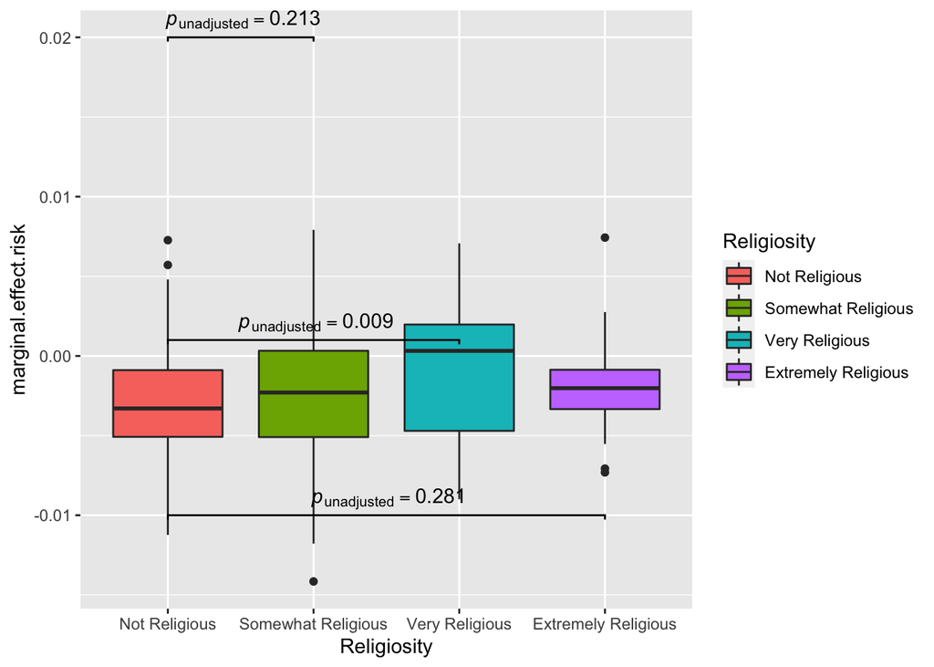

Predicting Gain given Continuous Religious

| term | estimate | std.error | statistic | p.value |
| --- | --- | --- | --- | --- |
| (Intercept) | 0.0032871 | 0.0002584 | 12.7231318 | 0.0000000 |
| ReligiousFactor | -0.0000872 | 0.0002489 | -0.3503491 | 0.7263571 |

Predicting Gain given Categorical Religious

[output not shown]

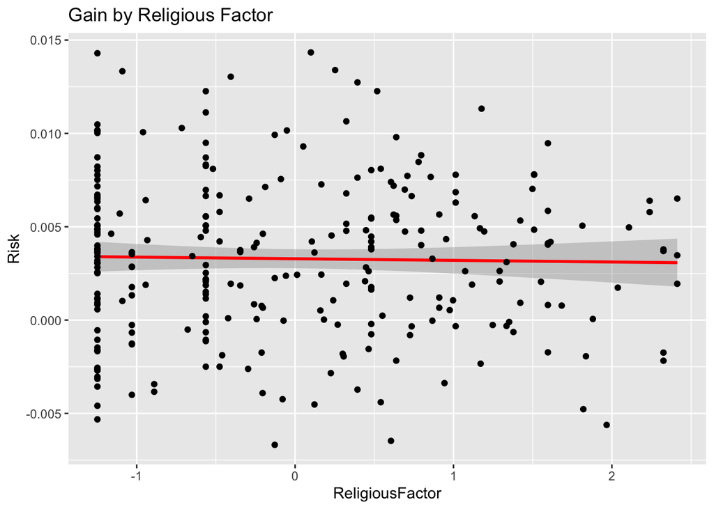

Descriptives for gain by religion

| ReligionNow_recode | n | mean | sd | se | ci |
| --- | --- | --- | --- | --- | --- |
| Christianity | 116 | 0.0031861 | 0.0040204 | 0.0003733 | 0.0007394 |
| Other | 24 | 0.0035586 | 0.0045462 | 0.0009280 | 0.0019197 |
| Not_religious | 125 | 0.0033288 | 0.0043226 | 0.0003866 | 0.0007652 |

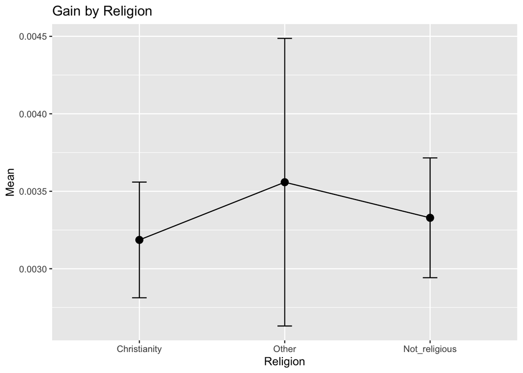

Descriptives for gain by religiosity

| Religiosity | n | mean | sd | se | ci |
| --- | --- | --- | --- | --- | --- |
| Not Religious | 135 | 0.0032467 | 0.0043184 | 0.0003717 | 0.0007351 |
| Somewhat Religious | 83 | 0.0035592 | 0.0043904 | 0.0004819 | 0.0009587 |
| Very Religious | 32 | 0.0036021 | 0.0030821 | 0.0005448 | 0.0011112 |
| Extremely Religious | 15 | 0.0014741 | 0.0039774 | 0.0010270 | 0.0022026 |

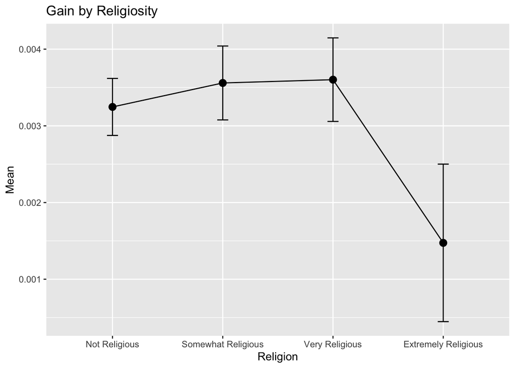

Pairwise comparisons for gain by religiosity

| group1 | group2 | mean.difference | p.value | significance | test.details |
| --- | --- | --- | --- | --- | --- |
| Not Religious | Extremely Religious | -0.0017726 | 0.1218435 | ns | Student's t-test |
| Not Religious | Somewhat Religious | 0.0003125 | 0.5938318 | ns | Student's t-test |
| Not Religious | Very Religious | 0.0003555 | 0.6669266 | ns | Student's t-test |
| Somewhat Religious | Extremely Religious | -0.0020851 | 0.0777054 | ns | Student's t-test |
| Somewhat Religious | Very Religious | 0.0000430 | 0.9608023 | ns | Student's t-test |
| Very Religious | Extremely Religious | -0.0021280 | 0.1062859 | ns | Student's t-test |

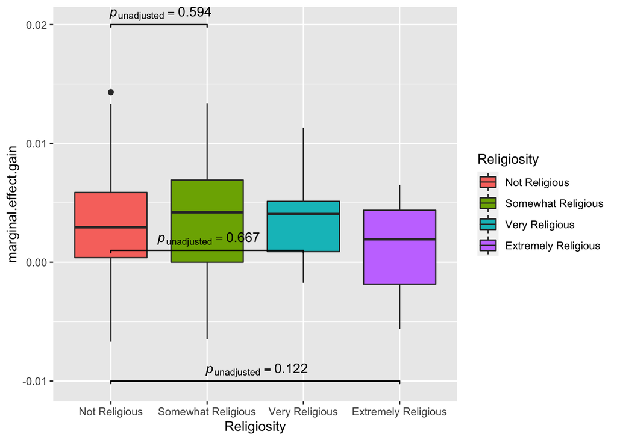

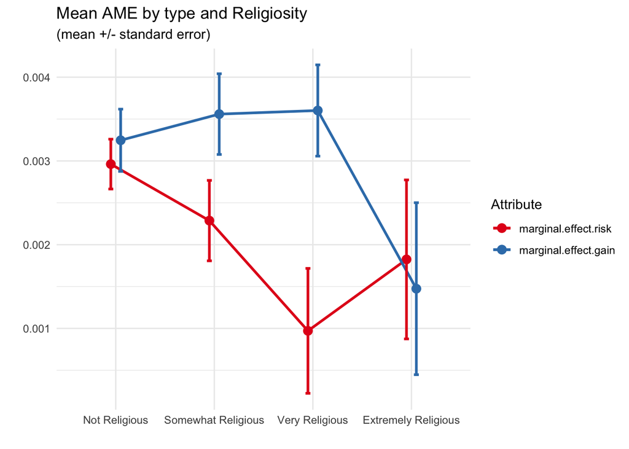

Predicting risk given mutltivariate

| term | estimate | std.error | statistic | p.value |
| --- | --- | --- | --- | --- |
| (Intercept) | -0.0030617 | 0.0012212 | -2.5071692 | 0.0128106 |
| religion | 0.0003200 | 0.0002721 | 1.1761321 | 0.2406698 |
| age | 0.0000097 | 0.0000225 | 0.4319060 | 0.6661850 |
| political | 0.0000669 | 0.0000382 | 1.7512683 | 0.0811360 |
| income | 0.0000000 | 0.0000000 | -0.9925737 | 0.3218852 |
| educationUndergraduate | 0.0005788 | 0.0005511 | 1.0502805 | 0.2946115 |
| educationPostgraduate | 0.0011006 | 0.0008427 | 1.3061172 | 0.1927228 |
| race_ethnicityWhite | 0.0002282 | 0.0009304 | 0.2452258 | 0.8064844 |
| race_ethnicityHispanic | 0.0008827 | 0.0013435 | 0.6570499 | 0.5117581 |
| race_ethnicityAsian | -0.0008389 | 0.0011237 | -0.7465267 | 0.4560564 |
| race_ethnicityOther | 0.0024270 | 0.0014110 | 1.7200259 | 0.0866752 |
| sexFemale | 0.0004527 | 0.0004924 | 0.9195116 | 0.3587215 |

Predicting gain given mutltivariate

[output not shown]